# L08 Factors

Data Science 1 with R (STAT 301-1)

Author

Allison Kane

**Github Repo Link**

[Allison Github Link](https://github.com/stat301-1-2023-fall/L08-factors-akane2460.git)

## Load packages

You should always begin by loading all necessary packages towards the beginning of your document.

```r
# Loading package(s)
library(tidyverse)
library(forcats)
```

## Datasets

We will be using the `gss_cat` dataset that is included in the `forcats` package. To view the documentation for the dataset, use `?gss_cat`.

## Exercises

### Exercise 1

The variable `marital` has 6 levels: `"No answer"`, `"Never married"`, `"Separated"`, `"Divorced"`, `"Widowed"`, `"Married"`.

Reorder the levels to be `"Married"`, `"Never married"`, `"Separated"`, `"Divorced"`, `"Widowed"`, `"No answer"`.

This should be done within `mutate()` and store this new dataset as `gss_clean`.

Prove this was successful by making a simple bar chart.

**Solution**

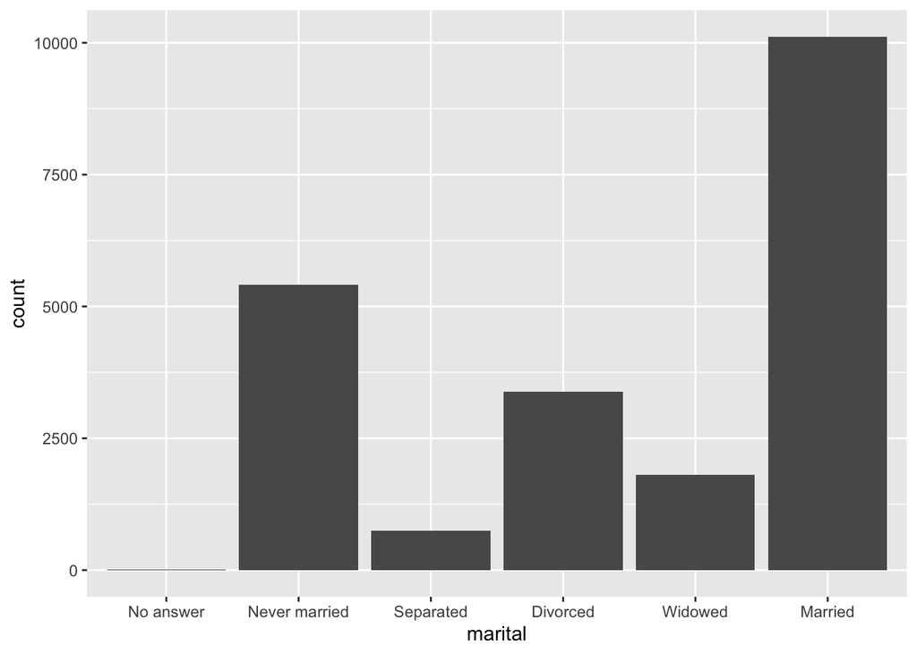

```r
gss_clean <- gss_cat |>
  mutate(
    marital = factor(marital,
                     levels = c("Married", "Never married", "Separated",
                                "Divorced", "Widowed", "No answer"))
  )

gss_cat |>
  ggplot(aes(x = marital)) +
  geom_bar()
```

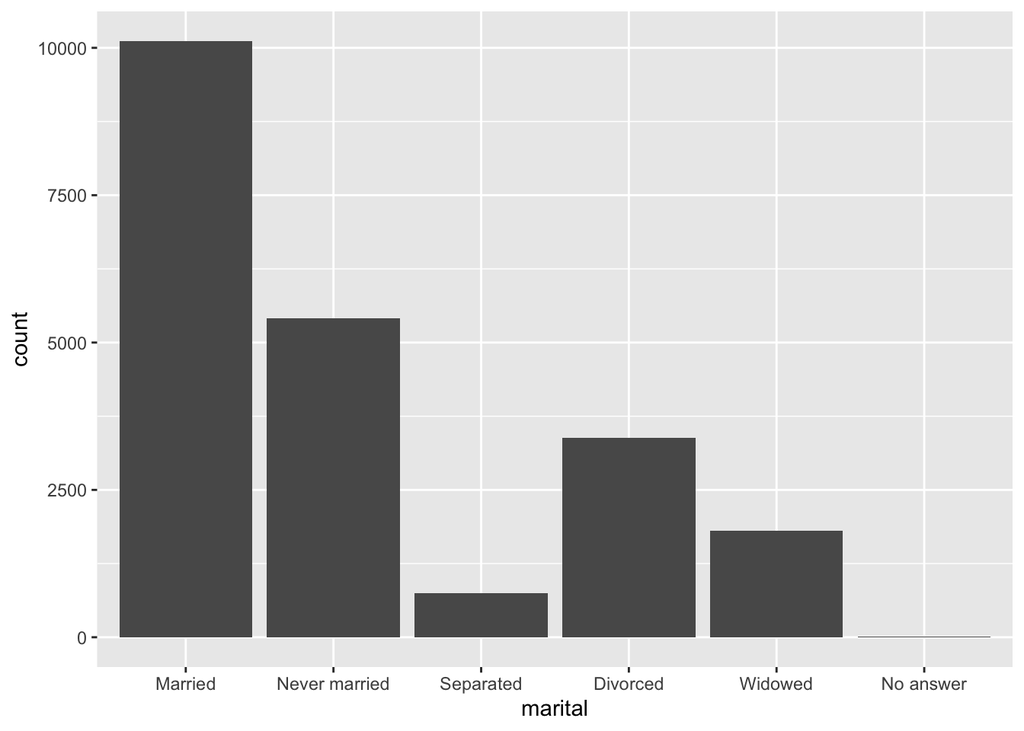

```r
gss_clean |>
  ggplot(aes(x = marital)) +
  geom_bar()
```

### Exercise 2

Starting from the `gss_clean` dataset from Exercise 1, change the level `"Never married"` to read as `"single"` and lowercase all the other levels ie: `"married"`, `"separated"`, …

This should be done within the `gss_clean` dataset, ie: do not store as a new dataset, overwrite `gss_clean`.

Prove this was successful by making a simple bar chart.

**Solution**

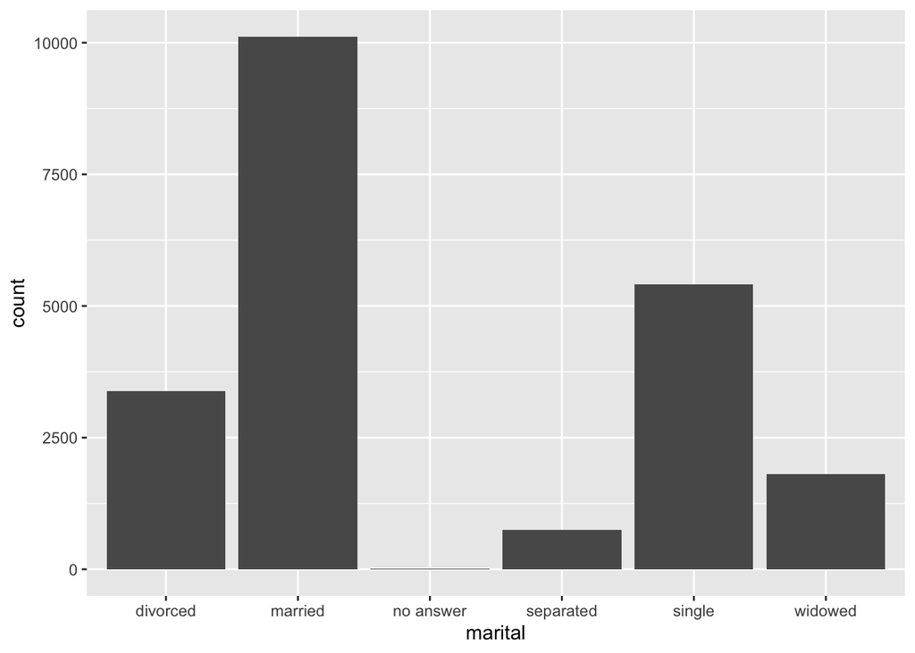

```r
gss_clean |>
  mutate(
    marital = recode(marital, "Never married" = "single"),
    marital = tolower(marital)) |>
  ggplot(aes(x = marital)) +
  geom_bar()
```

### Exercise 3

The variable `race` has 4 levels: `"Other"`, `"Black"`, `"White"`, `"Not applicable"`

Using your `gss_clean` dataset, demonstrate how to add the additional level options: `"Hispanic"`, `"Asian"`, `"American Indian"`.

Prove this was successful by running the line of code `levels(gss_clean$race)`

**Solution**

```r
gss_clean <- gss_clean |>
  mutate(
    race = factor(race, levels = c("Not applicable",
                           "Black",
                           "White",
                           "Hispanic",
                           "Asian",
                           "American Indian")
    )
  )

levels(gss_clean$race)
```

```
[1] "Not applicable"  "Black"           "White"           "Hispanic"
[5] "Asian"           "American Indian"
```

### Exercise 4

What happens when you are defining levels in a `factor` with the `levels` argument and either do not define a level that exists in the dataset or have a typo in a level that exists in the dataset?

**Solution**

In this situation, a new level will be created matching the typo and replacing the previous level in the dataset. The replaced value of the level becomes “NA” in the dataset.